# Lista 4 TRI

Davi Wentrick Feijó

2023-10-23

##### 1) Use (ou adapte) o codigo R no arquivo “saresp-codigo.txt” para fazer a equalizacao entre as proficiencias dos alunos do turno da noite e da manha que fizeram a prova de Lingua Portuguesa do SARESP em 2007. Expresse as proficiencias dos alunos do turno da noite na escala das proficiencias dos alunos do turno da manhã.Os itens comuns nas provas da manhã e da noite sao os de números 15 a 19.

```r
dados <- read.table(file="saresp.txt")
gab2 <- read.table(file="saresp-gabarito.txt")
```

Separando por turno (Manha,Tarde,Noite)

```r
manha <- dados[dados[,4]=="m07",]
tarde <- dados[dados[,4]=="t07",]
noite <- dados[dados[,4]=="n07",]
```

Formatando as respostas para numerico

```r
# gabarito
gab3 <- matrix(9,nrow(gab2),ncol(gab2))
for (i in 1:nrow(gab3)) {
  for (j in 1:ncol(gab3)) {
    if (gab2[i,j]=="A") gab3[i,j] <- 1
    if (gab2[i,j]=="B") gab3[i,j] <- 2
    if (gab2[i,j]=="C") gab3[i,j] <- 3
    if (gab2[i,j]=="D") gab3[i,j] <- 4
  }
}

# respostas manha
resp.manha <- as.matrix(manha[,5:34])
resp.m <- matrix(9,nrow(resp.manha),ncol(resp.manha))
resp.m[resp.manha=="A"] <- 1
resp.m[resp.manha=="B"] <- 2
resp.m[resp.manha=="C"] <- 3
resp.m[resp.manha=="D"] <- 4

# respostas noite
resp.noite <- as.matrix(noite[,5:34])
resp.n <- matrix(9,nrow(resp.noite),ncol(resp.noite))
resp.n[resp.noite=="A"] <- 1
resp.n[resp.noite=="B"] <- 2
resp.n[resp.noite=="C"] <- 3
resp.n[resp.noite=="D"] <- 4
```

Formatando as respostas (certo = 1 e errado = 0)

```r
# manha
for (i in 1:nrow(resp.m)) {
  for (j in 1:ncol(resp.m)) {
    if ((resp.m[i,j]!=gab3[1,j])&&(resp.m[i,j]!=9)) resp.m[i,j] <- 0
    if (resp.m[i,j]==gab3[1,j]) resp.m[i,j] <- 1
  }
}
resp.m[resp.m==9] <- NA

# noite
for (i in 1:nrow(resp.n)) {
  for (j in 1:ncol(resp.n)) {
    if ((resp.n[i,j]!=gab3[3,j])&&(resp.n[i,j]!=9)) resp.n[i,j] <- 0
    if (resp.n[i,j]==gab3[3,j]) resp.n[i,j] <- 1
  }
}
resp.n[resp.n==9] <- NA
```

Obtendo as estimativas dos parametros dos itens

```r
# manhã
resp.m.tpm <- tpm(resp.m)
par.m.est <- coef(resp.m.tpm) # c, b, a

# noite
resp.n.tpm <- tpm(resp.n)
par.n.est <- coef(resp.n.tpm) # c, b, a
```

Estimação da proficiencia alunos

```r
# manhã
theta.m.est <- eap(resp.m, cbind(par.m.est[,3],par.m.est[,2],par.m.est[,1]), qu=normal.qu())
prof.m.est <- theta.m.est[,1]

# noite
theta.n.est <- eap(resp.n, cbind(par.n.est[,3],par.n.est[,2],par.n.est[,1]), qu=normal.qu())
prof.n.est <- theta.n.est[,1]
```

#### a) Faca a equalizacao via regressao linear.

Obtendo $\alpha$ e $\beta$ através do ajuste da reta de regressão

```r
reg.nm.b <- lm(par.m.est[15:19,2]~par.n.est[15:19,2]) # descobrindo o alpha e o beta
```

Usando a transformação $\hat\theta^m_n=\alpha \times \hat\theta_n + \beta$ para obter a proeficiência dos alunos da noite na escala dos alunos da manhã

```r
prof.nm.b <- reg.nm.b$coefficients[2]*prof.n.est + reg.nm.b$coefficients[1]
```

#### b) Faca graficos com as proficiencias equalizadas versus as proficiencias originais dos alunos do turno da noite. Interprete os resultados.

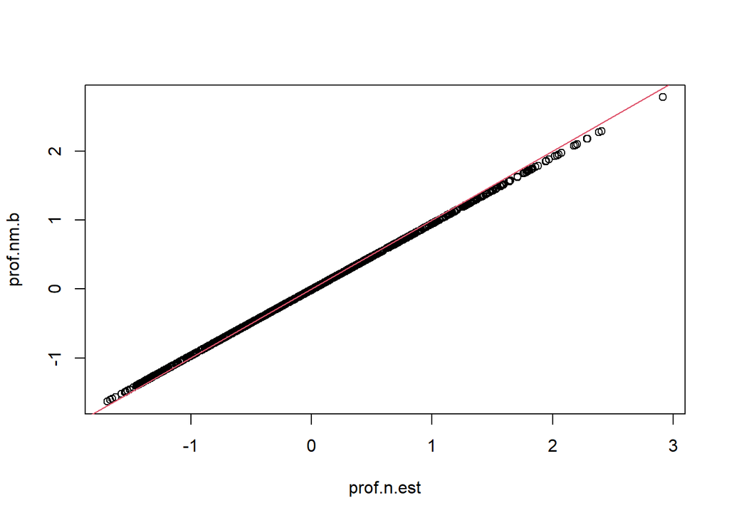

Com base no gráfico fornecido, é evidente que a proficiência estimada se assemelha bastante à proficiência equalizada, uma vez que a maioria dos valores está localizada na proximidade da linha vermelha.

#### c) Faca a equalizacao via metodo media-desvio.

Obtendo $\alpha$ e $\beta$ através da formula: $\alpha = \frac{S_1}{S_2}$ e $\beta = M_1 - \alpha \times M_2$

```r
alfa <- sd(par.m.est[15:19,2])/sd(par.n.est[15:19,2])
beta <- mean(par.m.est[15:19,2])-alfa*mean(par.n.est[15:19,2])
```

Utilizando a transformação $\hat\theta^m_n=\alpha \times \hat\theta_n + \beta$ para calcular a proficiência dos alunos da noite na escala dos alunos de manha.

```r
prof.nm <- alfa*prof.n.est+beta
```

#### d) Faca graficos com as proficiencias equalizadas versus as proficiencias originais dos alunos do turno da noite. Interprete os resultados.

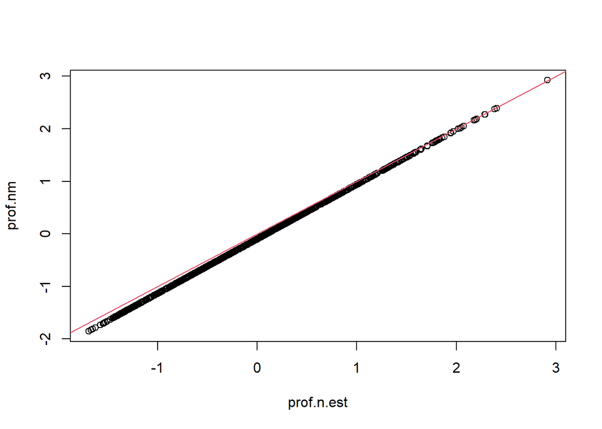

De maneira similar à equalização por meio de regressão linear, observa-se que a proficiência estimada através do desvio padrão apresenta uma notável semelhança com a proficiência equalizada